# Ancient cities and inscriptions

# Task 6: Select inscriptions that fall into the cities’ buffer

Now that you have both the cities and inscriptions in the same CRS, you can pick the inscriptions which fall within 5km radius of the ancient places in order to locate “urban” inscriptions. Use the inverse `st_difference` to locate “rural” inscriptions.

To reduce the computational intensity of the final intersection, it is a good idea to limit the dissolved city buffer object only to the area within the convex hull of the inscriptions. For the convex hull, you will need to combine the inscriptions into a MULTIPOINT feature using `st_union()`.

- Ensure that the spatial reference system in `cities_5km` buffer object and `insc_sf4326` is consistent.
- Create a convex hull for the inscriptions and use it to clip the city buffers object. Check the metadata of the `cities_it` object
- Combine the city buffers into a single multipolygon
- Use `st_intersection()` to select only the inscriptions that fall within the buffer object and assign these `insc_urban` object
- Use `st_difference()` to select inscriptions outside these buffers and create `insc_rural` object
- Plot and inspect the results: are the rural and urban inscriptions where you would expect them?

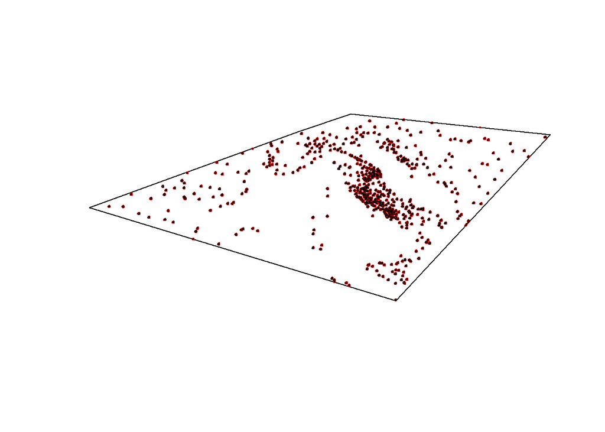

```r
# Project the sf object into EPSG3035 so it is consistent with cities and their
# buffers
i_sf3035 <- st_transform(i_sf4326, crs = 3035)


# Create a convex hull around the inscriptions's points dissolved into a
# MULTIPOINT
insc_ch <- st_convex_hull(st_union(i_sf3035))

# Select cities that fall within the convex hull of the inscriptions
cities_it <- st_intersection(insc_ch, st_transform(cities_5km))

# Dissolve the 399 city buffers into a single MULTIPOLYGON buffer feature
c_buff <- st_union(cities_it)

# Plot these interim results
plot(insc_ch)
plot(cities_it, border = "red", lwd = 2, add = TRUE)
plot(c_buff, add = TRUE)
```

```r
# Calculate the number of inscriptions in urban and rural areas. This may take
# a couple seconds
insc_urban <- st_intersection(i_sf3035, c_buff)
insc_rural <- st_difference(i_sf3035, c_buff)

# calculating ratio
nrow(insc_urban)/nrow(i_sf3035)
```

```
[1] 0.8667771
```

```r
nrow(insc_urban)/nrow(insc_rural)
```

```
[1] 6.506219
```

### Question:

*4. What is the ratio of urban to rural inscriptions?*

- around 86.68% is urban inscriptions, in other way, there is around 6.5 times more urban inscriptions than rural ones